# Homework 05

A skill for STAT 432 to help improve graphs and plots by enhancing the colors, scales, labels, etc. without chaning the underlying data. This will help make the graph more visually appealing and descriptive than one that simply displays the data.

Set a random seed before each simulation question and report it. You may use standard packages unless a question asks you to write the calculation yourself. Use equal neighbor weights throughout. Here $p$ counts the covariates used to measure distance; do not add an intercept column to a KNN predictor matrix. R and Python use different random-number generators, so their exact simulation results need not agree.

## Question 1: Estimate the bias and variance of KNN

In our previous homework, we used repeated simulations to study the behavior of linear regression estimators. We will now use the same idea for KNN. Consider the regression model

$$Y_i=f(\mathbf X_i)+\epsilon_i,
\qquad
f(\mathbf x)=0.5x_1+\sin(x_2)-0.3x_3^2,$$

where the three covariates are independent standard normal variables and $\epsilon_i\sim\mathcal N(0,0.1^2)$ independently of the covariates and other observations. Generate $n=400$ training observations. Our goal is to estimate the mean response at

$$\mathbf x_0=(0.5,0.7,1)^{\mathsf T}.$$

Use Euclidean distance and consider $k=1,3,5,\ldots,29$.

1. Calculate $f(\mathbf x_0)$. Generate one training dataset and obtain the KNN prediction at $\mathbf x_0$ for each value of $k$.

   **Show the workflow**

   ```r
   set.seed(seed = 9)
   ```

   **Show the workflow**

   ```r
   n = 400
   x1 = rnorm(n)
   x2 = rnorm(n)
   x3 = rnorm(n)
   X = c(x1, x2, x3)
   fx = 0.5*x1 + sin(x2) - 0.3*(x3^2)
   e = rnorm(n, 0, 0.1^2)
   Y = fx + e
   ks = c(1,3,5,7,9,11,13,15,17,19,21,23,25,27,29)
   x0 = matrix(data = c(0.5,0.7,1), nrow = 3, ncol = 1)
   x0
   ```

   ```
        [,1]
   [1,]  0.5
   [2,]  0.7
   [3,]  1.0
   ```

   **Show the workflow**

   ```r
   X = cbind(x1, x2, x3)
   X = data.frame(X)
   fx = 0.5*X[,1] + sin(X[,2]) - 0.3*(X[,3])^2
   e = rnorm(n, 0, 0.1)
   Y = fx + e
   ```

   **Show the workflow**

   ```r
   fx0 = 0.5*0.5 + sin(0.7) -0.3*(1^2)
   ```

   **Show the workflow**

   ```r
   library(kknn)
   ```

   **Show the workflow**

2. Independently repeat the generation of the training covariates and responses 200 times. Within each repetition, use the same training data for every value of $k$. Store the predictions in a matrix with 200 rows and one column for each value of $k$. Use this matrix to estimate the bias, variance, and mean squared error of the estimated mean response. Use divisor 200 when calculating the empirical variance, and verify numerically that

$$\text{mean squared error}
=\text{squared bias}+\text{variance}.$$

Plot squared bias, variance, and mean squared error against $k$ in one figure. Explain the pattern and compare it with the bias-variance trade-off for ridge regression or lasso.

**Show the workflow**

```r
ks = c(1,3,5,7,9,11,13,15,17,19,21,23,25,27,29)

test.pred = matrix(data = NA, nrow = 200, ncol = 15)
for(i in 1:200){
  x1 = rnorm(n)
  x2 = rnorm(n)
  x3 = rnorm(n)
  X = cbind(x1, x2, x3)
  X = data.frame(X)
  fx = 0.5*X[,1] + sin(X[,2]) - 0.3*(X[,3])^2
  e = rnorm(n, 0, 0.1)
  Y = fx + e
  for (j in seq_along(ks)){
  knn.fit = kknn(Y ~ ., train = data.frame(X, Y),
                 test = data.frame(x1 = 0.5, x2 = 0.7, x3 = 1),
                 k = ks[j], kernel = "rectangular")
  test.pred[i, j] = knn.fit$fitted.values
  }
}
```

**Show the workflow**

```r
bias = colMeans(test.pred) - fx0
bias
```

```
 [1] -0.01678646 -0.03313417 -0.05490408 -0.05666354 -0.06464457 -0.06820786
 [7] -0.07467362 -0.08001524 -0.08159922 -0.08955526 -0.09883862 -0.10391611
[13] -0.10560073 -0.11142788 -0.11963934
```

**Show the workflow**

```r
colnames(test.pred) = ks
```

**Show the workflow**

```r
test.pred2 = as.data.frame(test.pred)
```

**Show the workflow**

```r
variance = (sapply(test.pred2, function(x){
  mean((x-mean(x))^2)
}))
```

**Show the workflow**

```r
mse = colMeans(test.pred - fx0)^2
bias^2 + variance
```

```
         1          3          5          7          9         11         13
0.03841449 0.01584201 0.01734058 0.01445611 0.01402905 0.01298021 0.01407677
        15         17         19         21         23         25         27
0.01413127 0.01397574 0.01522697 0.01717294 0.01742897 0.01726434 0.01863346
        29
0.02005798
```

**Show the workflow**

```r
mse
```

```
           1            3            5            7            9           11
0.0002817854 0.0010978733 0.0030144578 0.0032107564 0.0041789207 0.0046523115
          13           15           17           19           21           23
0.0055761491 0.0064024388 0.0066584334 0.0080201443 0.0097690721 0.0107985589
          25           27           29
0.0111515132 0.0124161720 0.0143135719
```

**Show the workflow**

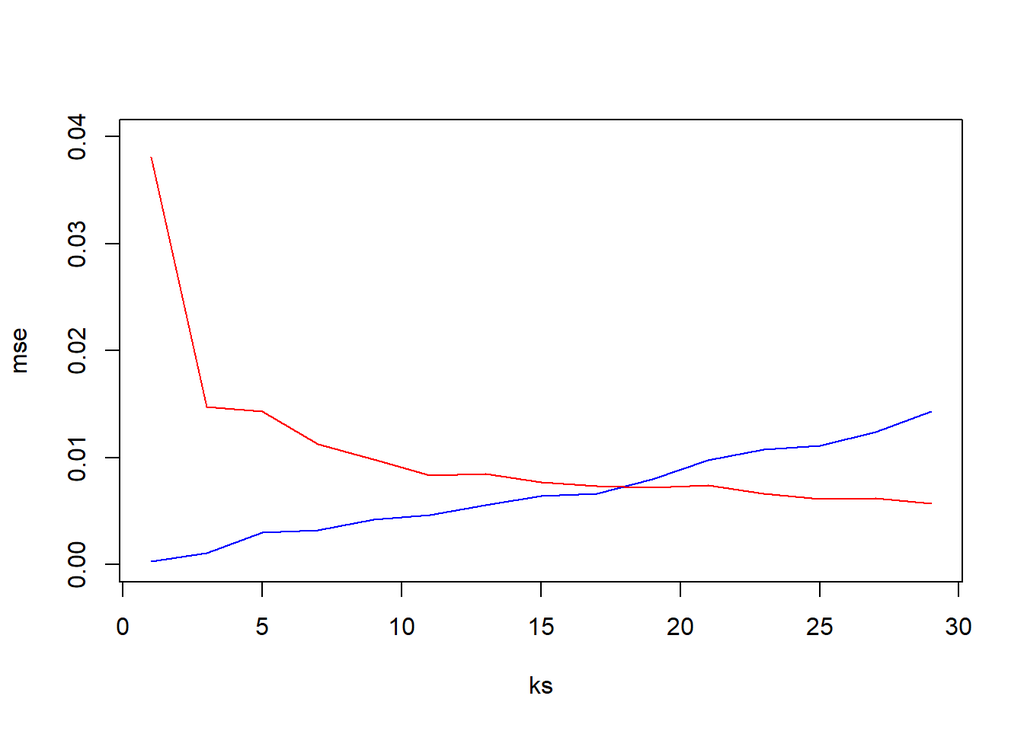

```r
bias2 = bias^2
plot(x = ks, y = mse, type = "l", col = "purple", ylim = c(0, 0.04))
lines(x = ks, bias2, col = "blue")
lines(x = ks, variance, col = "red")
```

AI Plot from Question 5:

**Show the workflow**

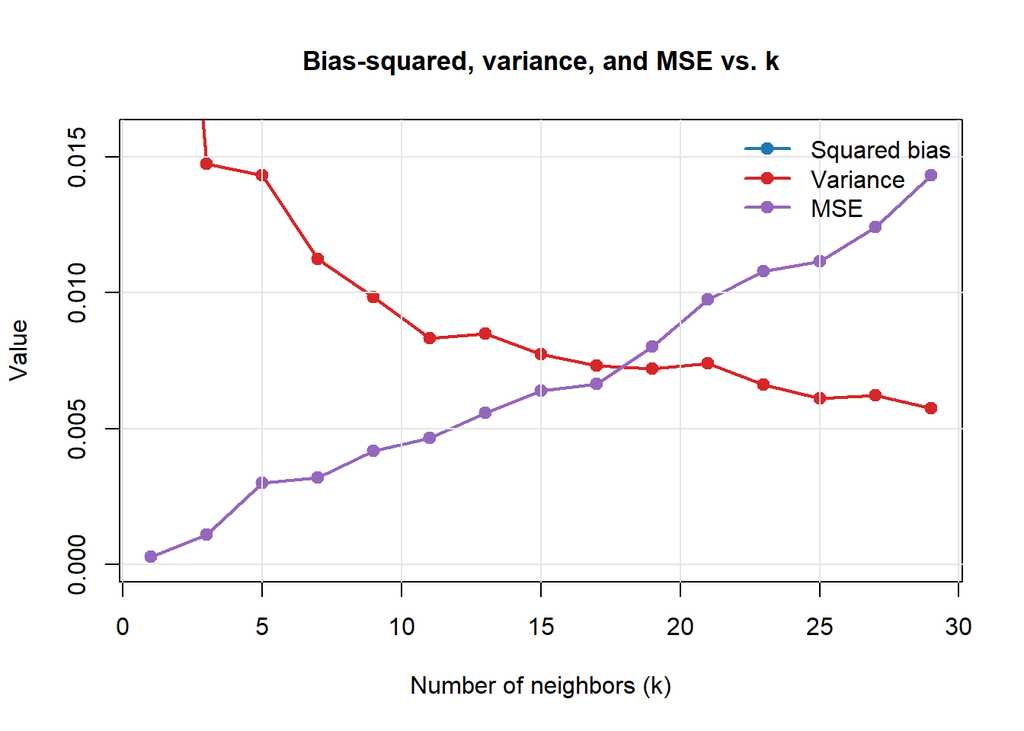

```r
bias2 = bias^2

plot_df <- data.frame(
  k = ks,
  bias2 = bias2,
  variance = variance,
  mse = mse
)

matplot(
  x = plot_df$k,
  y = cbind(plot_df$bias2, plot_df$variance, plot_df$mse),
  type = "o",
  pch = 19,
  lty = 1,
  lwd = 2,
  col = c("#1f77b4", "#d62728", "#9467bd"),
  xlab = "Number of neighbors (k)",
  ylab = "Value",
  main = "Bias-squared, variance, and MSE vs. k",
  ylim = c(0, max(plot_df$mse, na.rm = TRUE) * 1.1),
  xlim = range(ks),
  cex.main = 1.1
)

grid(col = "gray90", lty = 1)

legend(
  "topright",
  legend = c("Squared bias", "Variance", "MSE"),
  col = c("#1f77b4", "#d62728", "#9467bd"),
  lty = 1,
  lwd = 2,
  pch = 19,
  bty = "n"
)
```

## Question 2: Compare KNN with lasso

Use the response model from Question 1, including the noise standard deviation $0.1$, but generate $p=30$ covariates. The response still depends only on the first three. Consider these two settings:

- **Setting 1:** all 30 covariates are independent standard normal variables.
- **Setting 2:** the covariates have a multivariate normal distribution with mean zero and covariance matrix $\boldsymbol\Sigma$, where

  $$\Sigma_{jj}=1,
  \qquad
  \Sigma_{jl}=0.8\quad\text{for }j\ne l.$$

In each setting, generate 400 training observations and 1,000 independent test observations. Fit 5NN using Euclidean distance on the supplied covariate scale. All covariates already have population variance one.

For lasso, use a linear model containing the 30 covariates and a separately fitted, unpenalized intercept. Follow the Week 4 objective,

$$L_\lambda(\boldsymbol\beta)
=\frac{1}{2n}\left\lVert
\widetilde{\mathbf y}-\mathbf X\boldsymbol\beta
\right\rVert_2^2
+\lambda\lVert\boldsymbol\beta\rVert_1,$$

where $\mathbf X\in\mathbb R^{n\times30}$ contains the centered and standardized covariates and $\widetilde{\mathbf y}$ is the centered training response. Select the penalty by ten-fold cross-validation over 41 logarithmically spaced values from $10^{-4}$ to $1$. Estimate all means and scales using only the training portion of each fold, with divisor equal to that portion’s sample size. After selecting the penalty, refit on all training observations and apply the fitted transformations unchanged to the test observations. Do not add nonlinear terms to the lasso model.

1. Fit both methods in each setting. Use the same training and test data for the two methods within a setting. Report their test MSE values in one table, together with the selected lasso penalty and the number of nonzero lasso slopes. You only need to generate one dataset for each setting; repeated simulations are not required.

   **Show the workflow**

   ```r
   # setting 1
   x1 = rnorm(n)
   x2 = rnorm(n)
   x3 = rnorm(n)
   x4 = rnorm(n)
   x5 = rnorm(n)
   x6 = rnorm(n)
   x7 = rnorm(n)
   x8 = rnorm(n)
   x9 = rnorm(n)
   x10 = rnorm(n)
   x11 = rnorm(n)
   x12 = rnorm(n)
   x13 = rnorm(n)
   x14 = rnorm(n)
   x15 = rnorm(n)
   x16 = rnorm(n)
   x17 = rnorm(n)
   x18 = rnorm(n)
   x19 = rnorm(n)
   x20 = rnorm(n)
   x21 = rnorm(n)
   x22 = rnorm(n)
   x23 = rnorm(n)
   x24 = rnorm(n)
   x25 = rnorm(n)
   x26 = rnorm(n)
   x27 = rnorm(n)
   x28 = rnorm(n)
   x29 = rnorm(n)
   x30 = rnorm(n)
   X = cbind(x1, x2, x3, x4, x5, x6, x7, x8, x9, x10, x11, x12, x13, x14, x15, x16, x17, x18, x19, x20, x21, x22, x23, x24, x25, x26, x27, x28, x29, x30)
   X_tr = as.data.frame(X, nrow = 400, ncol = 30)
   fx_tr = 0.5*X_tr[,1] + sin(X_tr[,2]) - 0.3*(X_tr[,3])^2
   e_tr = rnorm(n, 0, 0.1)
   Y_tr = fx_tr + e_tr
   train_df = data.frame(X_tr, Y_tr)

   x1t = rnorm(n)
   x2t = rnorm(n)
   x3t = rnorm(n)
   x4t = rnorm(n)
   x5t = rnorm(n)
   x6t = rnorm(n)
   x7t = rnorm(n)
   x8t = rnorm(n)
   x9t = rnorm(n)
   x10t = rnorm(n)
   x11t = rnorm(n)
   x12t = rnorm(n)
   x13t = rnorm(n)
   x14t = rnorm(n)
   x15t = rnorm(n)
   x16t = rnorm(n)
   x17t= rnorm(n)
   x18t = rnorm(n)
   x19t = rnorm(n)
   x20t = rnorm(n)
   x21t = rnorm(n)
   x22t= rnorm(n)
   x23t = rnorm(n)
   x24t = rnorm(n)
   x25t= rnorm(n)
   x26t = rnorm(n)
   x27t = rnorm(n)
   x28t = rnorm(n)
   x29t = rnorm(n)
   x30t = rnorm(n)

   X_t = cbind(x1t, x2t, x3t, x4t, x5t, x6t, x7t, x8t, x9t, x10t, x11t, x12t, x13t, x14t, x15t, x16t, x17t, x18t, x19t, x20t, x21t, x22t, x23t, x24t, x25t, x26t, x27t, x28t, x29t, x30t)
   X_test = as.data.frame(X_t, nrow = 1000, ncol = 30)
   fx_test = 0.5*X_test[,1] + sin(X_test[,2]) - 0.3*(X_test[,3])^2
   e_test = rnorm(n, 0, 0.1)
   Y_test = fx_test + e_test
   test_df = data.frame(X_test, Y_test)

   knn.fit = kknn(Y ~ ., train = train_df,
   test = test_df, k = 5, kernel = "rectangular")
   setting1_p = knn.fit$fitted.values
   setting1_mse = mean((setting1_p-Y_test)^2)
   ```

   **Show the workflow**

   ```r
   setting1_mse
   ```

   ```
   [1] 1.087999
   ```

   **Show the workflow**

   ```r
   # setting 1 - lasso
   library(glmnet)
   ```

   **Show the workflow**

   ```r
   lambda_seq = 10^seq(-4,0, length.out = 41)

   x_means = colMeans(X_tr)
   x_center = sweep(X_tr, 2, x_means)
   x_scales = sqrt(colSums(x_center^2)/400)
   x_train_std = sweep(x_center, 2, x_scales, "/")
   y_mean = mean(Y_tr)
   y_centered = Y_tr - y_mean

   x_test_center1 = sweep(X_test, 2, x_means)
   x_test_std1 = sweep(x_test_center1, 2, x_scales, "/")

   lambda_search = cv.glmnet(as.matrix(x_train_std), y_centered, alpha = 1, lambda = lambda_seq, nfolds = 10, intercept = FALSE, standardize = FALSE)
   best_lamb = lambda_search$lambda.min
   lasso = glmnet(as.matrix(x_train_std), y_centered, alpha = 1, lambda = best_lamb, intercept = FALSE, standardize = FALSE)

   pred = predict(lasso, s = best_lamb, newx = as.matrix(x_test_std1)) + y_mean
   mse1 = mean((pred - Y_test)^2)
   mse1
   ```

   ```
   [1] 0.2808432
   ```

   **Show the workflow**

   ```r
   coef1 = coef(lasso, s = best_lamb)
   num_nonzero1 = sum(coef1[-1,1] != 0)
   num_nonzero1[1]
   ```

   ```
   [1] 10
   ```

   **Show the workflow**

   ```r
   library(MASS)
   ```

   **Show the workflow**

   ```r
   # setting 2
   cov_matr = matrix(0.8, nrow = 30, ncol = 30)
   diag(cov_matr) = 1
   mu = rep(0, times = 30)

   X_test2 = as.data.frame(mvrnorm(n = 1000, mu = mu, Sigma = cov_matr))
   fx_test2 = 0.5*X_test2[,1] + sin(X_test2[,2]) - 0.3*(X_test2[,3])^2
   e_test2 = rnorm(1000, 0, 0.1)
   Y_test2 = fx_test2 + e_test2
   test_df2 = data.frame(X_test2, Y_test2)

   X_train2 = as.data.frame(mvrnorm(n = 400, mu = mu, Sigma = cov_matr))
   fx_train2 = 0.5*X_train2[,1] + sin(X_train2[,2]) - 0.3*(X_train2[,3])^2
   e_train2 = rnorm(400, 0, 0.1)
   Y_train2 = fx_train2 + e_train2
   train_df2 = data.frame(X_train2, Y_train2)

   knn.fit2 = kknn(Y_train2 ~ ., train = train_df2,
                  test = test_df2, k = 5, kernel = "rectangular")
   setting2_p = knn.fit2$fitted.values
   setting2_mse = mean((setting2_p-Y_test2)^2)
   setting2_mse
   ```

   ```
   [1] 0.1870172
   ```

   **Show the workflow**

   ```r
   x_means2 = colMeans(X_train2)
   x_center2 = sweep(X_train2, 2, x_means2)
   x_scales2 = sqrt(colSums(x_center2^2)/400)
   x_train_std2 = sweep(x_center2, 2, x_scales2, "/")
   Y_train2 <- as.numeric(fx_train2 + e_train2)
   y_mean2 = mean(Y_train2)
   y_centered2 = Y_train2 - y_mean2

   x_center22 = sweep(X_test2, 2, x_means2)
   x_test_std22 = sweep(x_center22, 2, x_scales2, "/")

   lambda_search2 = cv.glmnet(as.matrix(x_train_std2), as.numeric(y_centered2), alpha = 1, lambda = lambda_seq, nfolds = 10, intercept = FALSE, standardize = FALSE)
   best_lamb2 = lambda_search2$lambda.min
   lasso2 = glmnet(as.matrix(x_train_std2), y_centered2, alpha = 1, lambda = best_lamb2, intercept = FALSE, standardize = FALSE)

   pred22 = predict(lasso2, s = best_lamb2, newx = as.matrix(x_test_std22)) + y_mean2
   mse22 = mean((pred22 - Y_test2)^2)
   mse22
   ```

   ```
   [1] 0.2652465
   ```

   **Show the workflow**

   ```r
   coef22 = coef(lasso2, s = best_lamb2)
   coef22
   ```

   ```
   31 x 1 sparse Matrix of class "dgCMatrix"
               s=0.01995262
   (Intercept) .
   V1          0.4331088027
   V2          0.5393556462
   V3          .
   V4          .
   V5          .
   V6          .
   V7          .
   V8          .
   V9          .
   V10         .
   V11         .
   V12         .
   V13         0.0219897911
   V14         .
   V15         .
   V16         0.0188638476
   V17         .
   V18         .
   V19         .
   V20         .
   V21         .
   V22         0.0116198685
   V23         .
   V24         .
   V25         .
   V26         0.0008561814
   V27         0.0206102053
   V28         .
   V29         0.0038342561
   V30         .
   ```

   **Show the workflow**

   ```r
   num_nonzero2 = sum(coef22[-1,1] != 0)
   num_nonzero2[1]
   ```

   ```
   [1] 8
   ```

   **Show the workflow**

   ```r
   results <- data.frame(
     Method = c("5NN", "LASSO", "5NN","LASSO"),
     Setting = c(1,1,2,2),
     Test_MSE = c(setting1_mse, mse1, setting2_mse, mse22),
     Selected_Lambda = c(NA, best_lamb, NA, best_lamb2),
     Nonzero_Slopes = c(NA, num_nonzero1[1], NA, num_nonzero2[1])
   )

   results
   ```

   ```
     Method Setting  Test_MSE Selected_Lambda Nonzero_Slopes
   1    5NN       1 1.0879988              NA             NA
   2  LASSO       1 0.2808432      0.02511886             10
   3    5NN       2 0.1870172              NA             NA
   4  LASSO       2 0.2652465      0.01995262              8
   ```

2. Compare the results between the two settings. Explain how correlation can change the usefulness of Euclidean neighborhoods, and why lasso does not use all covariates in the same way as KNN.

   The lowest test MSE was for the 5 k-fold with the second setting where the covariates had a normal distribution. The MSE changed a lot for the 5 k-fold for setting 1 to setting 2, but the Lasso’s MSE did not change very much from one setting to another. For just setting 1, the test MSE was lower for Lasso, and for just setting 2, the test MSE was lower for the k-fold. This implies that when there is correlation, the k-fold is better in terms of the Euclidean distance because the points will be by each other. Lasso can set some of the covariates equal to 0, differently than KNN.
3. The response model contains $\sin(X_2)$ and $X_3^2$, but the lasso fit uses only linear terms. Explain how this difference affects the comparison. Would the results justify a general claim that correlation always helps KNN, or that one method is always better? Explain why.

   The KNN model incorporated some of the error because it could fit the data in more ways than just linearly since it has those extra terms. The difference affects the comparison because the models themselves are different, so it depends on whether those terms worked better for this data. No, you can’t use the results to justify a claim for all instances because finding which method is better depends on the situation, so you can’t say Lasso is always better than ridge or KNN without giving the larger context of how you made that decision.

## Question 3: Observed dimension and latent dimension

The lecture’s handwritten digit example shows that KNN can work with many measured covariates. We will use a simulation to investigate why the structure of those covariates matters.

Let $p=100$ be the number of observed covariates and let $m$ be the number of latent variables. For each observation, generate

$$\mathbf X_i=\mathbf A\mathbf Z_i+\boldsymbol\eta_i,
\qquad
Y_i=Z_{i1}+Z_{i2}+\epsilon_i,$$

where $\mathbf A\in\mathbb R^{100\times m}$ has independent entries from Uniform$[-2,2]$. The entries of $\mathbf Z_i\in\mathbb R^m$ and $\boldsymbol\eta_i\in\mathbb R^{100}$, and the scalar $\epsilon_i$, are independent standard normal variables, also independent of $\mathbf A$. Generate $\mathbf A$ once and use it for all training and test observations in that dataset.

Compare $m=3$ and $m=30$. In each setting, generate 200 training observations and 200 independent test observations. Fit KNN using only the 100 observed covariates in $\mathbf X$, with Euclidean distance on their generated scale. The latent variables in $\mathbf Z$ are used to generate the data but are not available to the fitted model. Consider $k=2,10,18,\ldots,82$.

1. Generate one dataset for each value of $m$. Fit KNN for every value of $k$ and calculate test MSE. Within a setting, use the same training and test observations for all values of $k$.

   **Show the workflow**

   ```r
   # setting of m = 3
   p = 100
   m = 3
   k = c(2,10,18,26,34,42,50,58,66,74,82)
   n_train = 200
   n_test = 200

   A = matrix(runif(p*m, min = -2, max = 2), nrow = p, ncol = m) # 100 rows, 3 cols
   Z_train = matrix(rnorm(n_train*m), nrow = n_train, ncol = m) # 200 rows, 3 cols
   err_train = matrix(rnorm(n_train*p), nrow = n_train, ncol = p) # 200 rows, 100 cols
   X_train = Z_train %*% t(A) + err_train
   Y_train = Z_train[,1] + Z_train[,2] + rnorm(n_train)

   Z_test = matrix(rnorm(n_test)*m, nrow = n_test, ncol = m)
   err_test = matrix(rnorm(n_test*p), nrow = n_test, ncol = p)
   X_test = Z_test %*% t(A) + err_test
   Y_test = Z_test[,1] + Z_test[,2] + rnorm(n_test)


   X_train = as.data.frame(X_train)
   X_test = as.data.frame(X_test)
   colnames(X_train) = paste0("x", 1:p)
   colnames(X_test) = paste0("x", 1:p)
   train_df = data.frame(Y = Y_train, X_train)
   test_df = data.frame(Y = Y_test, X_test)

   mse = numeric(length(k))

   for(j in seq_along(k)){
     fit = kknn(
       Y ~ ., train = train_df, test = test_df,
       k = k[j], kernel = "rectangular")
     pred = fit$fitted.values
     mse[j] = mean((pred - Y_test)^2)
   }

   results = data.frame(k = k, Test_MSE = mse)
   results
   ```

   ```
       k Test_MSE
   1   2 20.82682
   2  10 24.61765
   3  18 27.28254
   4  26 27.95022
   5  34 27.94992
   6  42 28.33320
   7  50 29.31090
   8  58 30.05455
   9  66 31.16617
   10 74 32.13125
   11 82 32.97030
   ```

   **Show the workflow**

   ```r
   # setting of m = 30
   p = 100
   m = 30
   k = c(2,10,18,26,34,42,50,58,66,74,82)
   n_train = 200
   n_test = 200

   A = matrix(runif(p*m, min = -2, max = 2), nrow = p, ncol = m) # 100 rows, 3 cols
   Z_train = matrix(rnorm(n_train*m), nrow = n_train, ncol = m) # 200 rows, 3 cols
   err_train = matrix(rnorm(n_train*p), nrow = n_train, ncol = p) # 200 rows, 100 cols
   X_train = Z_train %*% t(A) + err_train
   Y_train = Z_train[,1] + Z_train[,2] + rnorm(n_train)

   Z_test = matrix(rnorm(n_test*m), nrow = n_test, ncol = m)
   err_test = matrix(rnorm(n_test*p), nrow = n_test, ncol = p)
   X_test = Z_test %*% t(A) + err_test
   Y_test = Z_test[,1] + Z_test[,2] + rnorm(n_test)


   X_train = as.data.frame(X_train)
   X_test = as.data.frame(X_test)
   colnames(X_train) = paste0("x", 1:p)
   colnames(X_test) = paste0("x", 1:p)
   train_df = data.frame(Y = Y_train, X_train)
   test_df = data.frame(Y = Y_test, X_test)

   mse = numeric(length(k))

   for(j in seq_along(k)){
     fit = kknn(
       Y ~ ., train = train_df, test = test_df,
       k = k[j], kernel = "rectangular")
     pred = fit$fitted.values
     mse[j] = mean((pred - Y_test)^2)
   }

   results = data.frame(k = k, Test_MSE = mse)
   results
   ```

   ```
       k Test_MSE
   1   2 3.419811
   2  10 2.802051
   3  18 2.899004
   4  26 2.910853
   5  34 2.927020
   6  42 2.991814
   7  50 3.021358
   8  58 3.050856
   9  66 3.083419
   10 74 3.097452
   11 82 3.141962
   ```

2. Repeat the complete experiment 50 times, generating a new $\mathbf A$ and new observations in each repetition. Plot average test MSE against $k$, with one curve for each value of $m$. These curves compare the specified choices of $k$ in a controlled simulation; they are not a cross-validation procedure for selecting a final model.

   **Show the workflow**

   ```r
   # m = 3
   store_mse = matrix(NA, nrow = 50, ncol = length(k))
   k = c(2,10,18,26,34,42,50,58,66,74,82)

   for(i in 1:50){
     p = 100
     m = 3
     n_train = 200
     n_test = 200

     A = matrix(runif(p*m, min = -2, max = 2), nrow = p, ncol = m)
     Z_train = matrix(rnorm(n_train*m), nrow = n_train, ncol = m)
     err_train = matrix(rnorm(n_train*p), nrow = n_train, ncol = p) # 200 rows, 100 cols
     X_train = Z_train %*% t(A) + err_train
     Y_train = Z_train[,1] + Z_train[,2] + rnorm(n_train)

     Z_test = matrix(rnorm(n_test)*m, nrow = n_test, ncol = m)
     err_test = matrix(rnorm(n_test*p), nrow = n_test, ncol = p)
     X_test = Z_test %*% t(A) + err_test
     Y_test = Z_test[,1] + Z_test[,2] + rnorm(n_test)


     X_train = as.data.frame(X_train)
     X_test = as.data.frame(X_test)
     colnames(X_train) = paste0("x", 1:p)
     colnames(X_test) = paste0("x", 1:p)
     train_df = data.frame(Y = Y_train, X_train)
     test_df = data.frame(Y = Y_test, X_test)

     mse = numeric(length(k))

     for(j in seq_along(k)){
       fit = kknn(
         Y ~ ., train = train_df, test = test_df,
         k = k[j], kernel = "rectangular")
       pred = fit$fitted.values
       store_mse[i,j] = mean((pred - Y_test)^2)
     }
   }
   avg_mse = colMeans(store_mse)
   ```

   **Show the workflow**

   ```r
   # m = 30
   store_mse2 = matrix(NA, nrow = 50, ncol = length(k))
   k = c(2,10,18,26,34,42,50,58,66,74,82)

   for(i in 1:50){
     p = 100
     m = 30
     n_train = 200
     n_test = 200

     A = matrix(runif(p*m, min = -2, max = 2), nrow = p, ncol = m)
     Z_train = matrix(rnorm(n_train*m), nrow = n_train, ncol = m)
     err_train = matrix(rnorm(n_train*p), nrow = n_train, ncol = p) # 200 rows, 100 cols
     X_train = Z_train %*% t(A) + err_train
     Y_train = Z_train[,1] + Z_train[,2] + rnorm(n_train)

     Z_test = matrix(rnorm(n_test)*m, nrow = n_test, ncol = m)
     err_test = matrix(rnorm(n_test*p), nrow = n_test, ncol = p)
     X_test = Z_test %*% t(A) + err_test
     Y_test = Z_test[,1] + Z_test[,2] + rnorm(n_test)


     X_train = as.data.frame(X_train)
     X_test = as.data.frame(X_test)
     colnames(X_train) = paste0("x", 1:p)
     colnames(X_test) = paste0("x", 1:p)
     train_df = data.frame(Y = Y_train, X_train)
     test_df = data.frame(Y = Y_test, X_test)

     mse = numeric(length(k))

     for(j in seq_along(k)){
       fit = kknn(
         Y ~ ., train = train_df, test = test_df,
         k = k[j], kernel = "rectangular")
       pred = fit$fitted.values
       store_mse2[i,j] = mean((pred - Y_test)^2)
     }
   }
   avg_mse2 = colMeans(store_mse2)
   ```

   **Show the workflow**

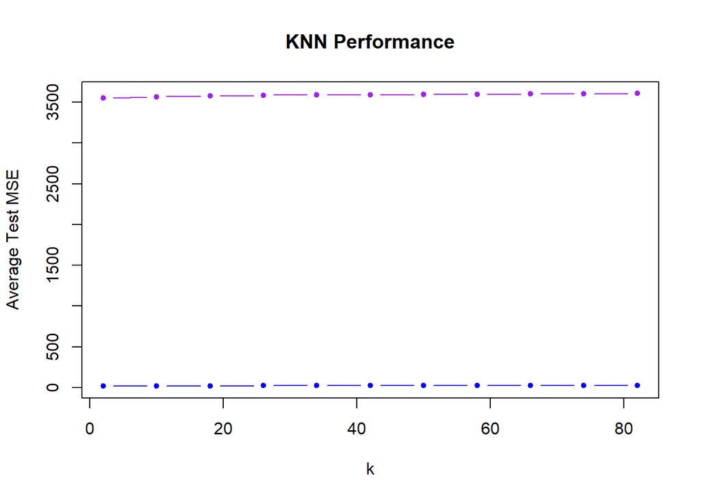

   ```r
   plot(k,avg_mse2, type = "b", pch = 20,col = "purple",ylim = range(c(avg_mse, avg_mse2)),xlab = "k",ylab = "Average Test MSE", main = "KNN Performance")
   lines(k, avg_mse, type = "b", pch = 20, col = "blue")
   ```

3. Both settings have 100 observed covariates, and the response depends on only two latent variables. Explain why their KNN performance can still differ. What role does the noise $\boldsymbol\eta_i$ play, and why are the observed data not confined exactly to an $m$-dimensional linear space?

## Question 4: Classify handwritten digits

Use `zip.train` and `zip.test` from the R package `ElemStatLearn`, as in the lecture. The package has been retired from the active CRAN repository. If needed, install the [archived package](https://cran.r-project.org/src/contrib/Archive/ElemStatLearn/ElemStatLearn_2015.6.26.2.tar.gz) into your usual R library, then load the two datasets. Python users can use the course copies of the same [training data](https://teazrq.github.io/stat432rpy/data/knn/zip-train.csv.gz) and [test data](https://teazrq.github.io/stat432rpy/data/knn/zip-test.csv.gz). These compressed CSV files have no headers and are included in the homework ZIP under `data/knn`. Run the Python code from the folder containing `data`.

Each image has $16\times16=256$ pixel values. The first column is the digit label and the remaining columns are the pixel values. Use the first 1,000 rows of `zip.train` and the first 500 rows of `zip.test`. Use the original pixel values without standardization, and do not include the digit label in a distance calculation.

For a test image $\mathbf x_0$ and a training image $\mathbf x_i$, the two distances are

$$d_E(\mathbf x_0,\mathbf x_i)
=\sqrt{\sum_{j=1}^{256}(x_{0j}-x_{ij})^2},
\qquad
d_M(\mathbf x_0,\mathbf x_i)
=\sum_{j=1}^{256}|x_{0j}-x_{ij}|.$$

1. Write a 5NN classification function that allows either Euclidean or Manhattan distance. For each test image, calculate its distances to the training images directly, find the five nearest, and return the most frequent digit label. Break distance ties by the smaller training row number and voting ties by the smallest digit. Do not use a built-in distance or KNN function for this part.

   **Show the workflow**

   ```r
   library(ElemStatLearn)
   ```

   **Show the workflow**

   ```r
   zip_train = ElemStatLearn::zip.train[1:1000,]
   zip_test = ElemStatLearn::zip.test[1:500, ]
   y_train = zip_train[,1]
   x_train = as.matrix(zip_train[,-1])
   y_test = zip_test[,1]
   x_test = as.matrix(zip_test[,-1])
   ```

   **Show the workflow**

   ```r
   euclidean_formula = function(x0, x_train){
     sqrt(rowSums(sweep(x_train, 2, x0, "-")^2))
   }
   manhattan_formula = function(x0, x_train){
     rowSums(abs(x_train - matrix(x0, 1000, ncol= length(x0), byrow = TRUE)))
   }
   ```

   **Show the workflow**

   ```r
   knn5_predict = function(x0, x_train, y_train, distance = "euclidean"){
     if(distance == "euclidean"){
       d = euclidean_formula(x0, x_train)
     }
     else if(distance == "manhattan"){
       d = manhattan_formula(x0, x_train)
     }
     nn = order(d)[1:5]
     neighbor_labels = y_train[nn]
     tab = table(neighbor_labels)
     winners = as.numeric(names(tab)[tab == max(tab)])
     prediction = min(winners)
     return(prediction)
   }
   ```

2. Apply the classifier to all 500 test images using each distance. For each fit, report the test classification error and a $10\times10$ confusion matrix, with rows representing predicted digits and columns representing true digits. Keep all digit labels from 0 through 9 in the matrix, including any with a zero count. Which digits are most often confused with one another?

   **Show the workflow**

   ```r
   pred_euclidean = numeric(nrow(x_test))

   for(i in 1:nrow(x_test)){
     pred_euclidean[i] = knn5_predict(
       x0 = x_test[i, ],
       x_train = x_train,
       y_train = y_train,
       distance = "euclidean"
     )
   }

   pred_manhattan = numeric(nrow(x_test))

   for(i in 1:nrow(x_test)){
     pred_manhattan[i] <- knn5_predict(
       x0 = x_test[i, ],
       x_train = x_train,
       y_train = y_train,
       distance = "manhattan"
     )
   }
   mean(pred_euclidean != y_test)
   ```

   ```
   [1] 0.122
   ```

   **Show the workflow**

   ```r
   mean(pred_manhattan != y_test)
   ```

   ```
   [1] 0.138
   ```

   **Show the workflow**

   ```r
   conf_euclidean = table(
     factor(pred_euclidean, levels = 0:9),
     factor(y_test, levels = 0:9))

   conf_euclidean
   ```

   ```
         0   1   2   3   4   5   6   7   8   9
     0 118   0   7   1   0   4   2   0   2   0
     1   0  66   0   0   2   0   0   0   0   1
     2   0   0  39   1   0   0   2   0   0   1
     3   0   0   0  23   0   4   0   0   2   0
     4   0   0   1   0  27   1   1   1   0   1
     5   0   0   0   1   0  13   0   0   0   0
     6   0   2   0   0   0   1  41   0   2   0
     7   0   0   0   0   1   1   0  34   0   4
     8   0   0   3   2   0   2   0   0  37   0
     9   1   0   0   1   4   0   0   1   1  41
   ```

   For the Euclidean distance, the numbers most often confused with each other were 0 and 2. This surprised me since they don’t look very similar. Overall, 0 was a commonly mistaken number compared to the other digits.

   **Show the workflow**

   ```r
   conf_manhattan = table(
     factor(pred_manhattan, levels = 0:9),
     factor(y_test, levels = 0:9))

   conf_manhattan
   ```

   ```
         0   1   2   3   4   5   6   7   8   9
     0 118   0   6   1   0   5   3   0   4   0
     1   0  67   2   0   2   0   1   0   0   1
     2   0   0  35   0   0   0   2   0   0   0
     3   0   0   1  24   0   4   0   0   2   0
     4   0   0   1   1  27   1   0   1   0   1
     5   0   0   0   1   0  11   0   0   0   0
     6   0   1   0   0   0   2  40   0   2   0
     7   0   0   2   1   1   0   0  34   0   5
     8   0   0   2   0   0   3   0   0  34   0
     9   1   0   1   1   4   0   0   1   2  41
   ```

   For the Manhattan distance, the digits most commonly confused with each other are 0 and 2 which is again interesting since they don’t look very similar. Overall though, most of the images were identified correctly.
3. For Euclidean distance, display three incorrectly classified test images, together with their true and predicted labels. Comment on whether the mistakes are visually understandable. Compare the overall results of the two distance measures. Can they have similar total error while making mistakes on different images? Use your predictions to support your answer.

   **Show the workflow**

   ```r
   compare_manhattan = data.frame(pred_manhattan, y_test)
   compare_euclidean = data.frame(pred_euclidean, y_test) # rows 4, 13, 14
   # row 4: predicted 0, actual 6
   # row 13: predicted 0, actual 2
   # row 14: predicted 7, actual 4
   ncol(zip_test)
   ```

   ```
   [1] 257
   ```

   **Show the workflow**

   ```
   [1] "digit  6  taken"
   ```

[figure not shown]

   ```r
   # image 4
   # predicted 0, actual 6
   image(zip2image(zip_test, 4), col=gray(256:0/256), zlim=c(0,1),
         xlab="", ylab="", axes = FALSE)
   ```

   This was predicted to be a 0 and is actually a 6. Visually, this makes sense because the 6 is written at a strong sideways angle and that makes it look much more like a 0

   **Show the workflow**

   ```
   [1] "digit  2  taken"
   ```

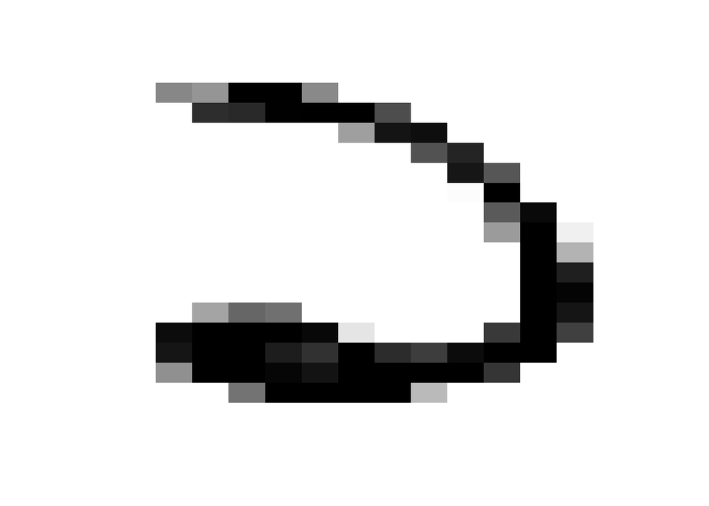

   ```r
   # image 13
   # predicted 0, actual 2
   image(zip2image(zip_test, 13), col=gray(256:0/256), zlim=c(0,1),
         xlab="", ylab="", axes = FALSE)
   ```

   This image is actually a 2 and was predicted to be a 0. This is honestly a really badly written 2 and does not look like a 2 at all. You can’t see the “tail” of the 2, so it just has the first loop, which then looks like a 0 that is missing one of the sides.

   **Show the workflow**

   ```
   [1] "digit  4  taken"
   ```

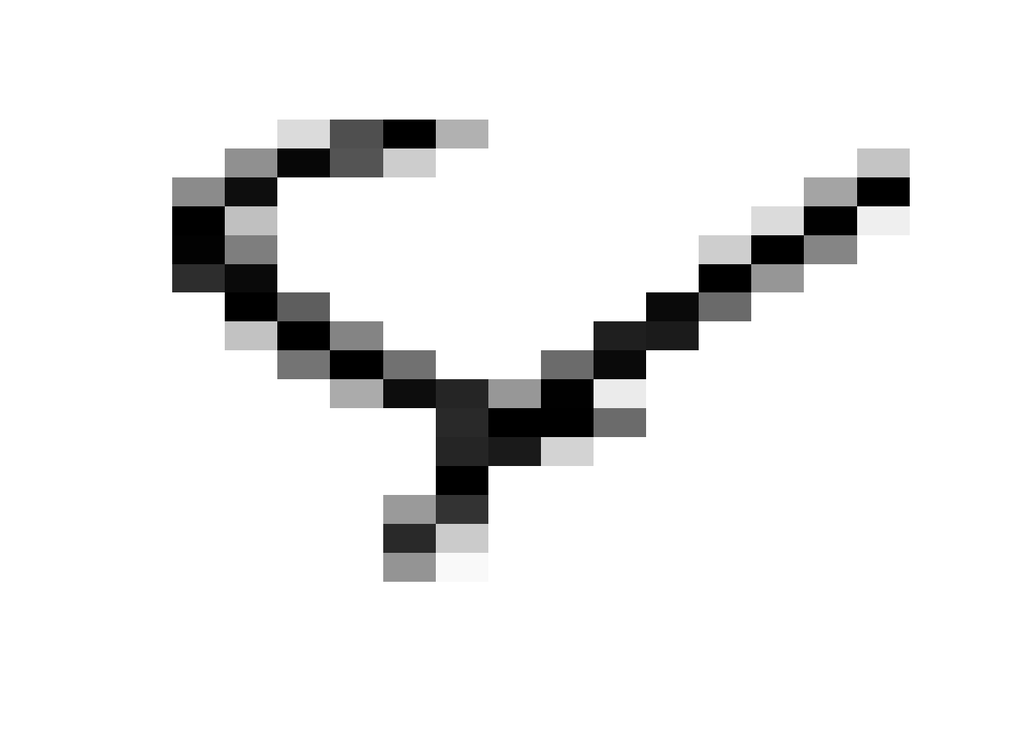

   ```r
   # image 14:
   # predicted 7, actual 4
   image(zip2image(zip_test, 14), col=gray(256:0/256), zlim=c(0,1),
         xlab="", ylab="", axes = FALSE)
   ```

   This image was predicted to be a 7 and is actually a 4. It does look like a 4, but if I didn’t know that’s what it was supposed to be, I don’t know if I’d be able to figure it out. It’s written at a slanted angle, but I also don’t think it really looks like a 7 either.

   **Show the workflow**

   ```r
   library(tidyverse)
   ```

   **Show the workflow**

   ```r
   compare_manhattan_euc = data.frame(pred_manhattan, pred_euclidean, y_test)
   both = compare_manhattan_euc %>%
     filter((pred_manhattan != pred_euclidean) & (pred_euclidean != y_test) )
   dim(both)
   ```

   ```
   [1] 11  3
   ```

   **Show the workflow**

   ```r
   euc = compare_manhattan_euc %>%
     dplyr::select(pred_euclidean, y_test) %>%
     filter(pred_euclidean != y_test)
   dim(euc)
   ```

   ```
   [1] 61  2
   ```

   **Show the workflow**

   ```r
   man = compare_manhattan_euc %>%
     dplyr::select(pred_manhattan, y_test) %>%
     filter(pred_manhattan != y_test)
   dim(man)
   ```

   ```
   [1] 69  2
   ```

## Question 5: Create a plot-formatting skill

Create a short `SKILL.md` file for improving the formatting of STAT 432 homework plots. You may use AI to help write it.

1. Include a title, a description, and a few formatting rules. The description should limit the skill to STAT 432 homework plot improvements and require an explicit request to use it. Your rules should address margins, titles, axes, labels, colors, and sizes for plots produced in R or Python. Keep them portable: do not refer to specific homework questions.
2. Ask your agent to install the skill. Explicitly call it to improve the plot from Question 1, then compare the original and revised versions. Do you like the changes? You may revise the skill and test it a couple more times, or uninstall it if it remains unhelpful. Yes! In question c, I explained in greater detail.
3. Append your final `SKILL.md` content to your submission and briefly explain your choices and experience. When I was thinking about the skill, my main priority was to give the skill space to make creative changes that I wouldn’t necessarily think of, so I intentionally did not outline all of the specific details about things like the point size to see what it would come up with. Just for fun, I added that I wanted the plots to be purple since that is what I normally set them to. To balance that out though, I made sure to include guidelines about when the skill should be used so that the creative liberties didn’t override my ideas in other parts of the project. When I installed the skill and ran it on the plot from Question 1, I really liked the improvements it made. Since I never remember to add a legend, I always have to scroll up and see what each color represents, so the skill adding that feature was very helpful. It also used my preferred purple color scheme and incorporated other colors that looked nice with it. Overall, I was happy with the results, and the only change I made was to write in the skill that I wanted it to adjust the margins as well. Below, I attached my skill.

# Instructions

Use this skill ONLY when explicitly instructed to do so by the user to help improve a plot. Examples of potential plots include scatter plots, boxplots, line graphs, and histograms. This will be used on STAT 432 homework exclusively.

Examine the contents of the plot and identify areas for improvement. Some examples of strong improvements include: adding a title, making the colors visually cohesive, clearer labels, a legend, and improving labels on the axes. If cohesive with the data context, purple is a preferred color for an element like a line or point. Ensure that the margins are adjusted properly to display all of the available data without some of it being cut off. Additionally, give suggestions about other potential ideas for the user to consider adding to the plot.

Do not solve other parts of the assignment or change the underlying data. Do not interpret the graph. Ask instead for clarification about the plot’s purpose or specific elements that the user would like improvement on. Offer actionable, small suggestions for enhancement. If the request is broader than plot editing or unclear, ask for more specific guidance.

# Rules

- Do not provide an explanation about what the graph represents, how to interpret it, or answer any other questions.
- Do not submit the assignment unless told to do so under the stat432-fall2026-student SKILL.
- Use this skill only when explicitly instructed to do so by the user.
- Do not change the underlying data.
- Do not make up information.
- Do not use code that is outside of the plot building.
- Do not delete any existing code unless specifically told to do so.